# Summative Assessment 1

Calpito, Casenas, de Leon, Lorenzo, Oba

June 29, 2022

## **The Monty Hall Problem**

### **The Monty Hall Problem**

[figure not shown]

**The Let’s Make a Deal game show (Image from wilsongrowthpartners.com)**

The Monty Hall Problem is a brain teaser problem named after the host of *[Let’s Make a Deal](https://en.wikipedia.org/wiki/Let%27s_Make_a_Deal)*, an American game show on which it originated. In the show, contestants were asked to pick among three doors; whatever’s behind it is for them to win. Behind one is a brand new car, while the remaining two doors each conceal a goat. After the contestant’s pick, Monty Hall would always open a door, revealing a goat behind it. The contestant is allowed to switch to the remaining unopened door. Should they do it? Let’s try to answer that using probability.  
Before we start, why not give it a try first? [**Click here to play the Monty Hall game.**](https://math.andyou.com/tools/montyhallsimulator/montysim.htm)

### **Solving the Monty Hall Problem**

At first glance, it seems as though no matter what door you pick you’ll only have a 1/3 chance of winning the car. Psychologically speaking, it will also hurt more to lose something we might think we had the “chance” of getting but not holding for it. It will be easier to admit that we just truly lost staying our ground than to lose and feel as if we missed our chance by not trusting ourselves. It might feel a bit counter intuitive, but probability says otherwise.  
Indeed, at first, there’s a 1/3 chance that the car is behind the door picked and a 2/3 chance that it’s behind one of the remaining doors. The key lies in the fact that the second door opened by the host will certainly have a goat behind it. That information collapses the 2/3 chance of the car being in either one of the doors to only the one remaining door.

```r
knitr::include_graphics("https://brilliant-staff-media.s3-us-west-2.amazonaws.com/tiffany-wang/gWotbuEdYC.png")
```

[figure not shown]

**Image from Brilliant.org**

**Door You Picked**

| Winning Door | Door 1 | Door 2 | Door 3 |
| --- | --- | --- | --- |
| Door 1 | Stay | Switch | Switch |
| Door 2 | Switch | Stay | Switch |
| Door 3 | Switch | Switch | Stay |

We can see here that the best move is to switch 6/9 or 2/3 of the time, therefore, the wiser choice is to take the switch.  
Knowing this strategy doesn’t mean you’ll always win, though. There’s still a 1/3 chance you’ll lose by using this strategy. But it not only increases your chances of winning; it also guarantees a win in the long run.You can play using the strategy with this [website](https://math.andyou.com/tools/montyhallsimulator/montysim.htm) again.

## **Ultra Lotto Combinations**

### **Forcing an Ultra Lotto Win**

[figure not shown]

One of the most popular major games of PCSO is the Ultra Lotto 6/58. At ₱20 per ticket, how much would a bettor spend to cover all of the possible combinations. Would the grand prize of ₱50 million cover all the expenses or would it simply incur a massive loss on the bettor?

First, we need to find the number of possible combinations in Ultra Lotto 6/58. We should use combination since there are 58 choices and we only need to select 6, and the order of the numbers does not matter.

$58C6 = 40,475,358$

For Ultra Lotto 6/58, there are 40,475,358 possible combinations. Since 1 ticket equals 1 combination, and 1 ticket costs ₱20, the bettor would need to pay $40,475,358 * ₱20 = ₱809,507,160$, to cover all combinations. The grand prize, though, is just ₱50 million, which is less than the amount the bettor would wager. Therefore, placing a bet on every single possible combination in the Ultra Lotto 6/58 will result in a huge loss (worth ₱759,507,160) for the bettor.

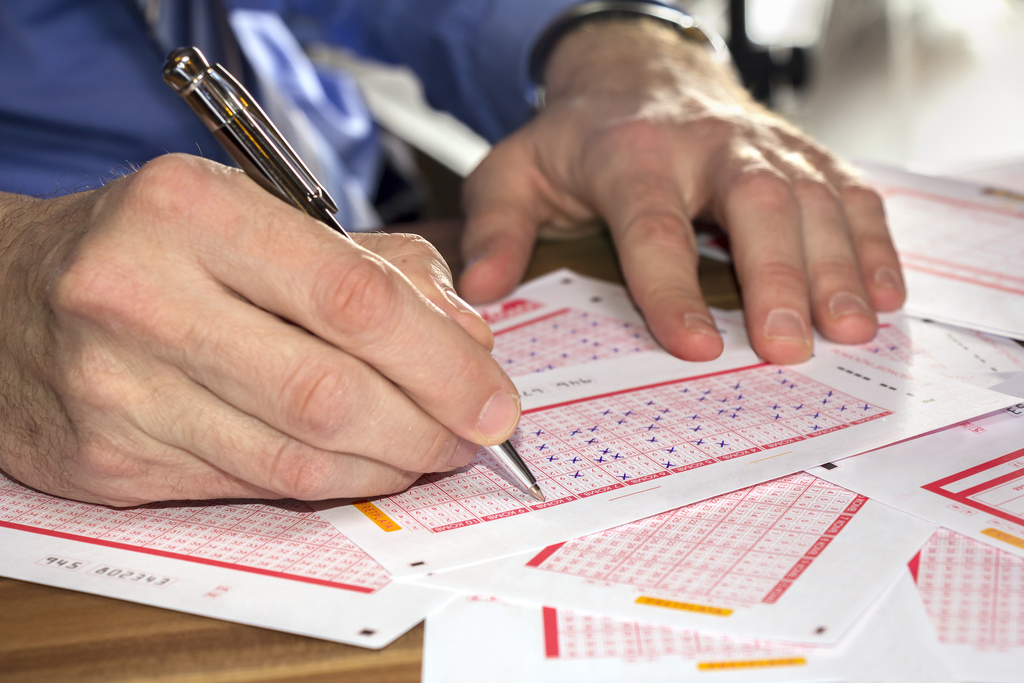

Still, it is obviously possible to win the 50 million without spending that much money, it’s just that the less you spend, the lower your chances. Nobody in their right mind would spend millions just for a small chance to win this lottery. Being something that isn’t guaranteed or even likely, it just isn’t worth it, no matter how much you spend. The way the lottery works is that it gets people’s hopes up by offering a “large” cash prize, which in reality is quite small compared to the amount of cash needed to actually win. This is why most of the winners are simply just extremely lucky, as they usually win at a large gain since they are somehow able to win with just a few combinations. With how probability works, no matter how small the chance, someone out there is still going to be able to win eventually.

If you are interested you can view the results from the most recent lotto from [**Click here to view the most recent results**](https://www.lottopcso.com/6-58-lotto-result/)